# Kaggle Report

Anderson Nelson

The dataset contains a listing of over 25,000 Airbnb rentals in New York City. The goal of this project is to predict the price for a rental using over 90 variables on the property, host, and past reviews, and to illustrate my thought process on model creation, and data exploration. My hypothesis on the variables that impact customer service are supply, demand, locations, customers services, size in square footage, type of property, capacity, certain amenities. Reviewing the variables of the data reveals the variables that belong in that category.

###### Data Cleaning

```r
dataset <- read.csv("analysisData.csv")
dataset <- select(id,host_id,zipcode,room_type,property_type,accommodates,host_since,host_response_time,bathrooms,bedrooms,beds,bed_type,price,neighbourhood_cleansed,neighbourhood_group_cleansed,availability_30,availability_60,availability_90,availability_365,number_of_reviews,is_business_travel_ready,cleaning_fee,host_is_superhost,review_scores_communication,reviews_per_month,review_scores_rating,review_scores_accuracy,review_scores_cleanliness,review_scores_checkin,review_scores_communication,review_scores_location,review_scores_value,calendar_updated,calculated_host_listings_count,require_guest_phone_verification,require_guest_profile_picture,cancellation_policy,instant_bookable,last_review,first_review,maximum_nights,minimum_nights,extra_people,guests_included,latitude,longitude,.data = dataset)
```

We now have an abridge version of this original dataset. The columns that were removed were one of the following of the following categories: duplicate, contributed to bias, nor relevant to the problem. Lets take a look at how many columns we have.

```r
dim(dataset)
```

```
## [1] 29142    45
```

```r
(sum(is.na(dataset)) / (ncol(dataset) * nrow(dataset))) * 100
```

```
## [1] 0.4361022
```

However in the scoring data zipcode also had a few missing data. I was able to combine both the zipcodes from both datasets, and removed all the duplicates. That allowed to me to see the neighborhoods clusters for each of the zipcode.Since there were only 93 misssing data, I joined the most recurring zipdode in to the scoring data by using the neighborhood grop.

```r
#zipcodena <- read.csv("zipcodena.csv")
#merge(x = zipcodena, y = na_zipcode)
#merger <- dataset%>%
# select(neighbourhood_cleansed, zipcode)%>%
# filter(is.na(zipcode))
#NEWZIP <- merge(x = zipcodena, y = merger)
#dataset$zipcode[is.na(dataset$zipcode)] <- NEWZIP$n
```

I also checked if there were any duplicated data, and the result indicate that there are none.

```r
sum(duplicated(x = dataset))
```

```
## [1] 0
```

The below illustrate the discritbuion of the price column, an interesing observation is the range, and that there are prices that are 0. it is unlikely that the seller would list their property for free. There are instances where that could occur but that’s most likely an outlier.

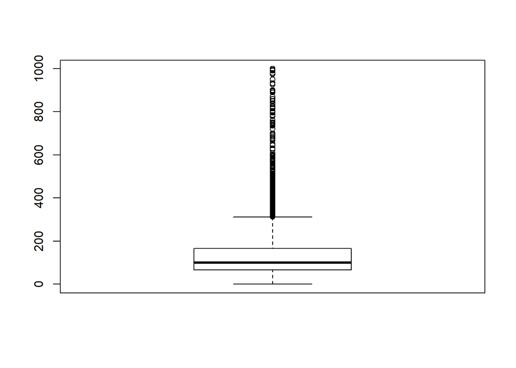

```r
boxplot(dataset$price)
```

```r
summary(dataset$price)
```

```
##    Min. 1st Qu.  Median    Mean 3rd Qu.    Max.
##       0      67     100     133     165     999
```

There are only 25 variables that are listed as 0, and it confirms my suspicion. It’s best to remove them.

```r
length(dataset$price[dataset$price == 0])
```

```
## [1] 25
```

```r
dataset <- dataset[!dataset$price == 0,]
```

A quick look at property type reveals that there are 35 unique property type. At first glance, it doesn’t make sense as to why there is that many. Lets take at look at the distribution of property accross the dataset.

```r
length(unique(dataset$property_type))
```

```
## [1] 35
```

```r
dataset%>%
 select(property_type)%>%
 count(property_type,sort = TRUE)%>%
 mutate(percentage = (n / sum(n)*100))%>%
 filter(percentage > 1)
```

```
## # A tibble: 5 x 3
##   property_type     n percentage
##   <fctr>        <int>      <dbl>
## 1 Apartment     24248      83.3
## 2 House          2400       8.24
## 3 Townhouse       729       2.50
## 4 Loft            705       2.42
## 5 Condominium     344       1.18
```

I’ve condense the remaining variables into one column called “other”.

```r
dataset$property_type[!dataset$property_type == "Apartment" & !dataset$property_type =="House" &
                        !dataset$property_type =="Loft" & !dataset$property_type =="Condominium"
                      & !dataset$property_type =="Townhouse"] <- "Other"
dataset$property_type<- droplevels(dataset$property_type)
```

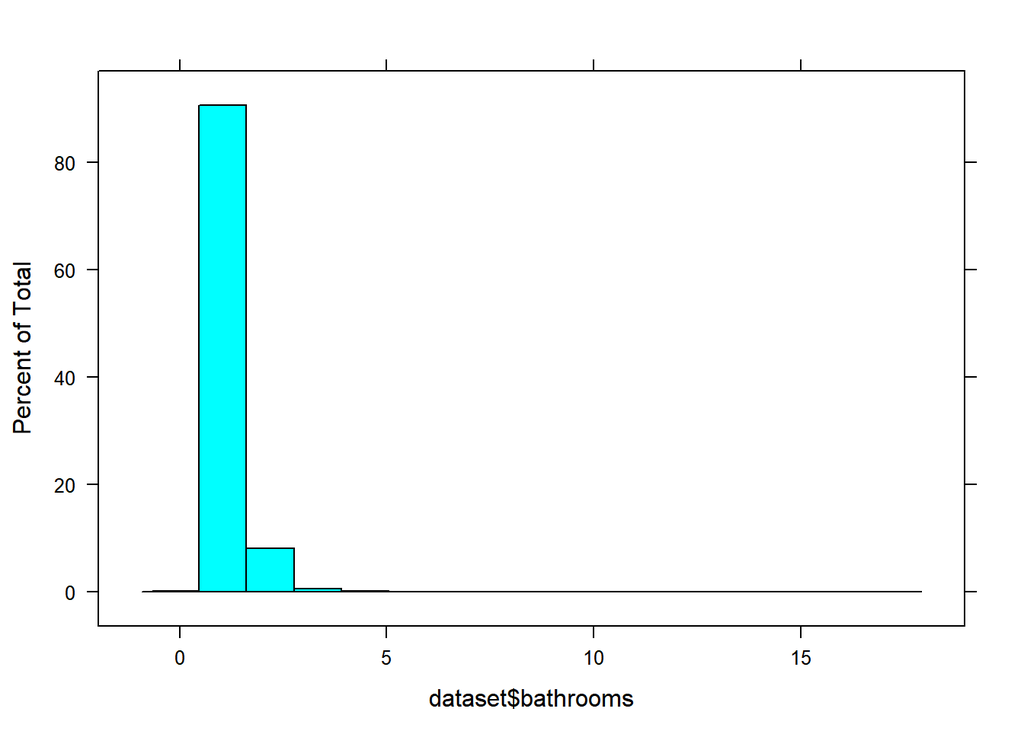

```r
histogram(dataset$bathrooms)
```

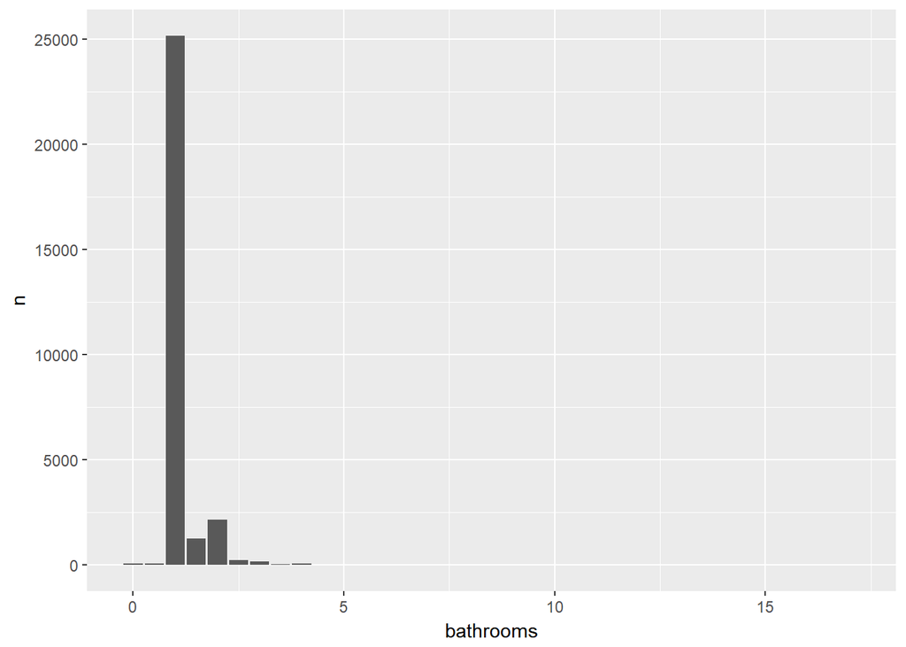

```r
dataset%>%
 select(bathrooms)%>%
 group_by(bathrooms)%>%
 count(bathrooms)%>%
 ggplot(aes(x = bathrooms, y = n)) + geom_bar(stat = "identity")
```

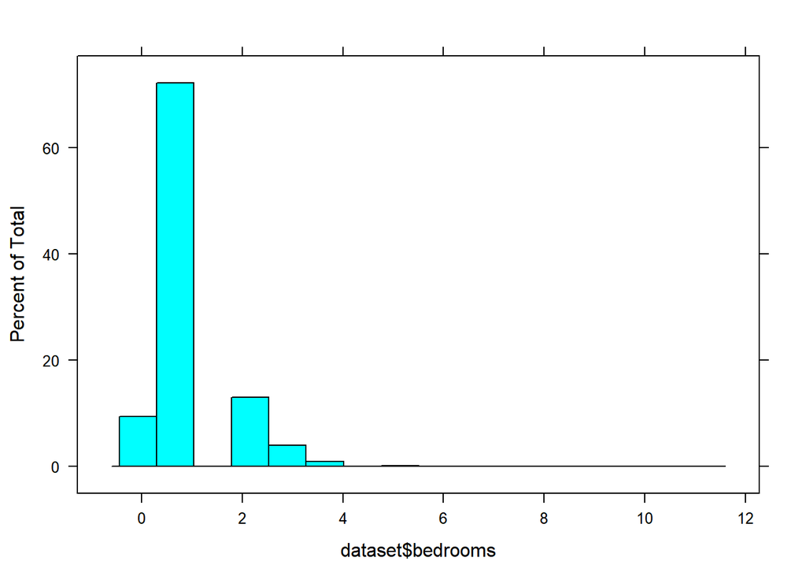

```r
histogram(dataset$bedrooms)
```

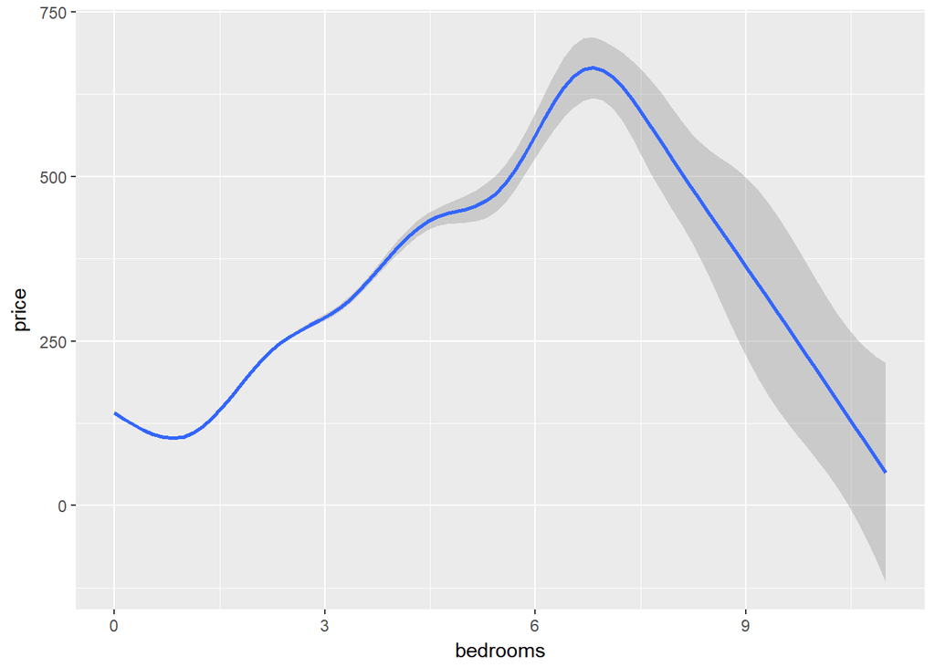

```r
dataset%>%
 select(bedrooms, price)%>%
 group_by(bedrooms)%>%
 ggplot(aes(x = bedrooms, y = price)) + geom_smooth()
```

```r
dataset%>%
 filter(bedrooms == 0)%>%
 select(room_type)%>%
 count(room_type)
```

```
## # A tibble: 3 x 2
##   room_type           n
##   <fctr>          <int>
## 1 Entire home/apt  2510
## 2 Private room      242
## 3 Shared room         2
```

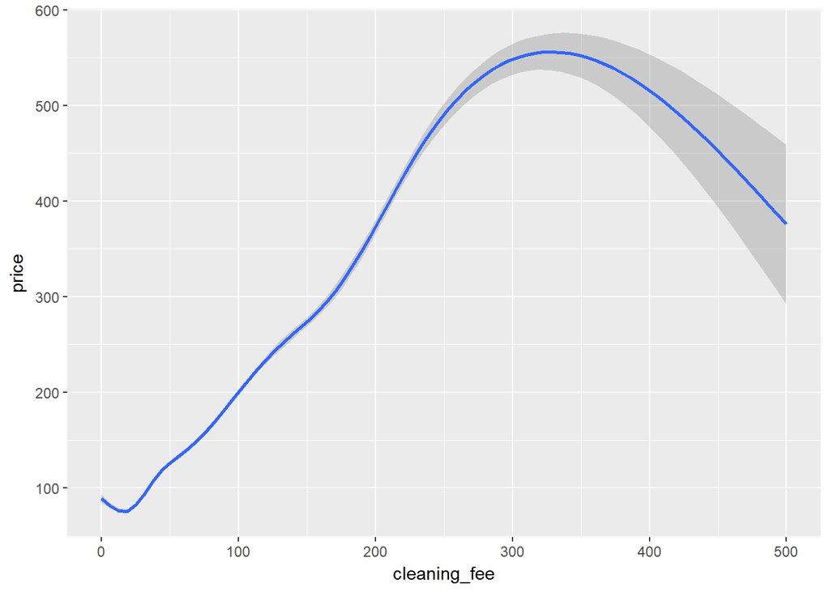

```r
dataset%>%
 select(cleaning_fee, price)%>%
 group_by(cleaning_fee)%>%
 ggplot(aes(x = cleaning_fee, y = price)) + geom_smooth()
```

```r
dataset$review_scores_sum <- dataset$review_scores_accuracy + dataset$review_scores_communication +
 dataset$review_scores_rating + dataset$review_scores_checkin + dataset$review_scores_cleanliness +
 dataset$review_scores_location + dataset$review_scores_value
```

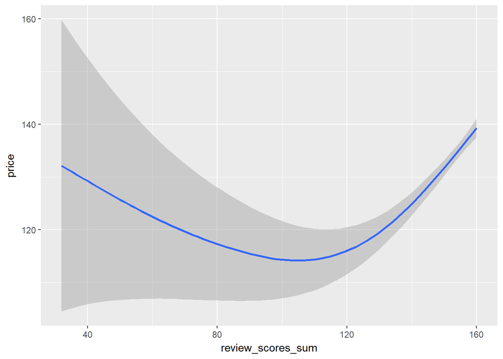

```r
dataset%>%
 select(review_scores_sum, price)%>%
 group_by(review_scores_sum)%>%
 ggplot(aes(x = review_scores_sum, y = price)) + geom_smooth()
```

# Models

```r
split <- sample.split(Y = dataset$price, SplitRatio = .8)
trainingset <- dataset[split,]
testset <- dataset[!split,]
```

```r
#subset1 <- regsubsets(price ~ .,
#                      data = trainingset,nvmax = 11); summary(subset1)

#subset_measures1 <- data.frame(model1 = 1:length(summary(subset1)$cp),cp = summary(subset1)$cp,
#                              bic = summary(subset1)$bic,
#                              adjr2 = summary(subset1)$adjr2); subset_measures1
```